# Importing the libraries

# Model selection

Going with the traditional machine learning models to achieve our classification task because, when i tried using pre trained model like roberta, the issue is that roberta only has three sentimental class positive, negative and neutral, but my feedback type has a 4th type irrevelent, after trying various methode roberta was not able to effectively differentiate irrevelent class. this is the reason for using traditional approch model.

**here is the image of the results from the roberta model without the irrevelent class (for reference only)**

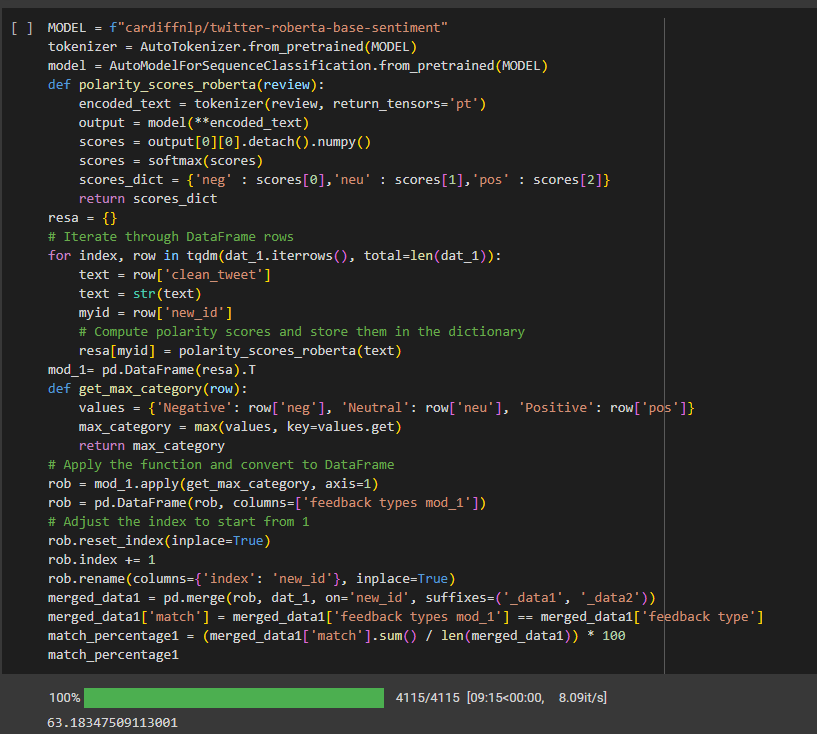

**here is a compar of Lightgbm and MultinomialNB**

# **Lightgbm**

```python
import sklearn.model_selection
import sklearn.feature_extraction.text
from sklearn.model_selection import train_test_split
import tensorflow as tf
import sklearn.ensemble
import lightgbm
parameters_grid = {
    "n_estimators" : [100,150],
    "learning_rate" : [0.07,0.1],
    "num_leaves" : [10,20]
}

model_lgbm = sklearn.model_selection.GridSearchCV(lightgbm.LGBMClassifier(objective='multiclass', force_col_wise=True, class_weight='balanced', random_state=0), parameters_grid, cv=5, scoring='f1_macro',n_jobs=-1)
model_lgbm.fit(X_train_res, y_train_res)
print("f1_macro score LightGBM Classifier: ",model_lgbm.best_score_)
print("Hyperparameters for training LightGBM Classifier: ",model_lgbm.best_params_)
```

[output not shown]

```python
lgbm_clf = lightgbm.LGBMClassifier(n_estimators=150, learning_rate=0.1, num_leaves=20 ,objective='multiclass', class_weight='balanced', force_col_wise=True,random_state=0,header=True)
lgbm_clf.fit(X_train_res, y_train_res)
```

```
[LightGBM] [Info] Total Bins 38866
[LightGBM] [Info] Number of data points in the train set: 16200, number of used features: 1439
[LightGBM] [Info] Start training from score -1.386294
[LightGBM] [Info] Start training from score -1.386294
[LightGBM] [Info] Start training from score -1.386294
[LightGBM] [Info] Start training from score -1.386294
```

```
LGBMClassifier(class_weight='balanced', force_col_wise=True, header=True,
               n_estimators=150, num_leaves=20, objective='multiclass',
               random_state=0)
```

Checking predictions various metrics of performance:

```python
y_pred = lgbm_clf.predict(X_test_combined)
clf_report = sklearn.metrics.classification_report(y_test, y_pred)
print(clf_report)
```

```
              precision    recall  f1-score   support

  Irrelevant       0.49      0.51      0.50      1169
    Negative       0.69      0.62      0.65      2008
     Neutral       0.51      0.63      0.56      1594
    Positive       0.62      0.56      0.59      1829

    accuracy                           0.58      6600
   macro avg       0.58      0.58      0.58      6600
weighted avg       0.59      0.58      0.59      6600
```

# **MultinomialNB**

```python
from sklearn.naive_bayes import MultinomialNB
model = MultinomialNB()
model.fit(X_train_res, y_train_res)
```

```
MultinomialNB()
```

```python
from sklearn.metrics import (accuracy_score,confusion_matrix,ConfusionMatrixDisplay, f1_score,classification_report,)
y_pred = model.predict(X_test_combined)
accuray = accuracy_score(y_pred, y_test)
f1 = f1_score(y_pred, y_test, average="weighted")
print("Accuracy:", accuray)
print("F1 Score:", f1)
```

```
Accuracy: 0.5859090909090909
F1 Score: 0.5833632180510573
```

# Discussion:

we can see that pre trained model is able to predect sentimental classes more effectivly but was not able to predict the class irrevelent.

Weaknesses of the solution used: the ML model did moderately perform well than pre trained model, this is because the model is trained with the same revelent datasets but does not have weights as pretrained model because the pretrained model is trained on more realtime data than our ML model

solution is to have a hybrid model which combains the advantages of our ML model for classifying irrevelnt model and using pretrained sentimental model like roberta for classifying positive, negative, and neutral class. this would would better of both model.